# Demo #5 - ABM project

2020-11-10

## Background

**Goal:**

> Replace the previous ABM i.e. Annual Bibliometric Monitoring / Årlig Bibliometrisk Uppföljning at KTH

**Summary:**

Our [previous demo meeting](https://KTH-Library.github.io/demo-4) was held 2020-05-26. After summer vacations we have worked on Sprints **17 to 23** (current).

The [ABM services at KTH](https://kth.se/abm) have been operational since the last demo meeting, with some maintenance and updates during autumn, for example involving server upgrades and rotation of certificates.

## Agenda

- Progress - What is **new** since last meeting?
- A short **demo** of the current work
- Update about **Scopus data integration**
- Update about **other efforts** (other data integration, APIs etc)
- Your **questions and feedback**, suggestions for future directions

## What is new?

- During the autumn, we have primarily focused on a proof of concept for author based reporting showing results at divisional level, based on currently employed researcher and their publication outputs.
- Data integration work has been initiated with regards to using Scopus data from Elsevier in order to complement the WoS data.

## Demo

- Introduction to [**current ABM**](https://abm.sys.kth.se/public/) for new attendees
- Background for new **author based POC** (Proof Of Concept)
- Demonstration of author based reporting for KTH divisions
  - Examples
    - A few **divisions** (sv. avdelningar)
    - A few **departments** (sv. institutioner) versus current ABM
  - Some observations and explanations of differences

## Author based selection of publications

- Organization based = **organizational affiliation** when publication was written
  - Usually used for reporting etc
  - Publications directly tied to organizational unit
- Author based = publications made by **currently employed researchers** at the unit
  - Usually used for prospective analysis, current “brain power”
- Aim in this case is still reporting for **KTH publications**
  - Fetch employees from **HR system / KTH APIs** and collect their publications
  - Can be strongly influenced by staff turnover, and interact with staff groups

## Author-based: Divisions

- Overview for KTH Divisions
- Examples
  - DIVISION OF ELECTRIC POWER AND ENERGY SYSTEMS: “j/jj/jjn”
  - DIVISION OF COMPUTATIONAL SCIENCE AND TECHNOLOGY: “j/jh/jhs”
  - DIVISION OF SPACE AND PLASMA PHYSICS: “j/jj/jje”
  - NUCLEAR ENGINEERING: “s/sh/shh”
  - MATERIALS AND NANOPHYSICS: “s/sk/skq”

## Author-based: Departments

- Examples - these can be compared against [current ABM](https://abm.sys.kth.se/public/)
  - Electrical engineering: “j/jj”
  - Computer Science: “j/jh”
  - Applied Physics: “s/sk”

## Author-based: Department summary

| Department | Publ, frac | cf 2015-2017 | Top10% | jcf 2016-2018 | Int. co-pub | Type |
| --- | --- | --- | --- | --- | --- | --- |
| Electrical engineering | 198.3 | 1.01 | 11,80% | 1.17 | 84% | org |
|  | 153.3 | 0.99 | 11,30% | 1.16 | 78% | author |
| Applied physics | 142.2 | 0.96 | 8,90% | 1.24 | 75% | org |
|  | 99.8 | 1.1 | 10,40% | 1.32 | 72% | author |
| Computer science | 195.6 | 1 | 9,10% | 1.52 | 73% | org |
|  | 137 | 1.31 | 13,00% | 1.52 | 70% | author |

## Author-based: Plan forward

- Classify which are research “divisions”
- Evaluate differences between models
  - Trends across time
  - Staff categories and staff turnover
  - Interaction with length of author lists
- Better understand HR/UG data
- Can people (and therefore publications) become ‘’lost’’ in administative subunits?

## Scopus data integration

- **Web of Science** data (Clarivate) used for ABM/ÅBU
- **Scopus** data (Elsevier) has been acquired
  - Better coverage of conference proceedings
  - Comparison of coverage Scopus vs WoS (2012–2019); download here
  - Plans to integrate in existing ABM app as complement to WoS

## Scopus coverage gain: publication types

- Coverage by publication type for all KTH peer-reviewed publications

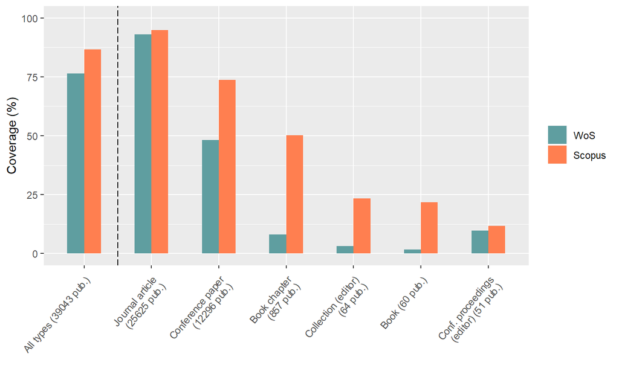

## Scopus coverage gain: KTH departments

- Distribution of KTH departments by coverage gain for peer-reviewed publications (all publication types)

  \(\scriptstyle \text{coverage gain } = \text{ Scopus coverage } - \text{ WoS coverage}\)

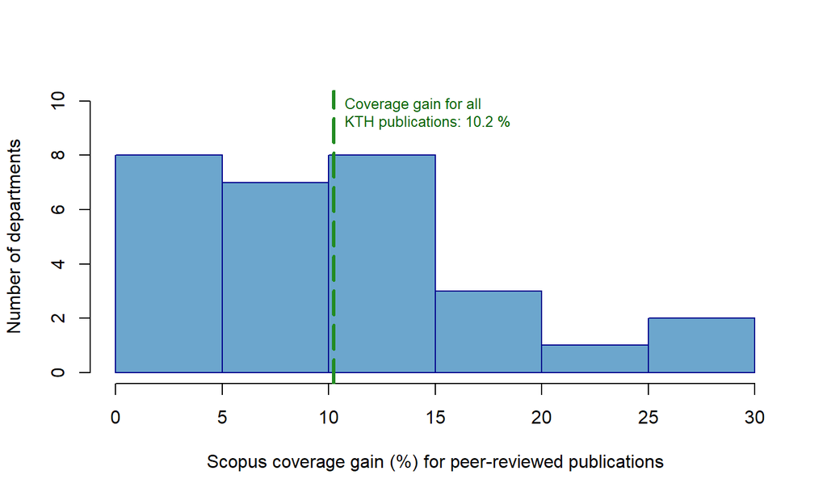

## Scopus coverage gain: example

- Department of Computer Science

| Publication type | Total publications | Publications in WoS | Publications in Scopus | WoS coverage (%) | Scopus coverage (%) | Scopus coverage gain (%) |
| --- | --- | --- | --- | --- | --- | --- |
| All journal articles | 921 | 835 | 863 | 90.66232 | 93.70250 | 3.040174 |
| Journal article, regular | 911 | 825 | 853 | 90.55982 | 93.63337 | 3.073546 |
| Conference paper | 1633 | 982 | 1429 | 60.13472 | 87.50765 | 27.372933 |
| Collection (editor) | 2 | 0 | 1 | 0.00000 | 50.00000 | 50.000000 |
| Book chapter | 36 | 5 | 23 | 13.88889 | 63.88889 | 50.000000 |
| Journal article, review/survey | 9 | 9 | 9 | 100.00000 | 100.00000 | 0 |
| Rapport | 3 | 0 | 0 | 0.00000 | 0.00000 | 0 |
| Book | 2 | 0 | 2 | 0.00000 | 100.00000 | 100.000000 |
| Journal article, book review | 1 | 1 | 1 | 100.00000 | 100.00000 | 0 |
| Other | 2 | 0 | 0 | 0.00000 | 0.00000 | 0 |

[output cut: 2 more lines]

## Other efforts

- All efforts are available at [KTH-Library@GitHub](https://github.com/kth-library)
- Further use of [`kthapi` R package](https://github.com/KTH-Library/kthapi) has been the basis for the author data in the POC
- A new R package [`semanticscholar`](https://github.com/KTH-Library/semanticscholar) allows for experimenting with data integration against this data source which provides open data for publications from many researchers at KTH.
- API for public data from ABM
  - https://bibliometrics.lib.kth.se/testapi/__swagger__/
- API for author based data (BETA)

[figure not shown]

## Operations and maintenance

- we have separated operational ABM services from other **KTHB Bibliometrics services** and have allowed external users without KTH accounts to log in via the use of https://auth0.com
- we have initiated a **migration away from Travis** - a continuous integration service provider - to using GitHub Actions.
- we have **upgraded** the software stack and server environment (and rotated certificates and API keys)
- we have continued to work with the KTH Web team on aligning with the **KTH style** for web applications

## Questions and feedback

## Questions and Answers

Please provide your input!

- Questions from the Zoom chat
- Suggestions and comments
- Future directions

Thank you for attending!